# R Notebook

Rich Chu, Matt Lawson

# Lab 7: Five Scores and Several Months Ago

## Part I: Import and Look

### Problem 1

```r
quiz <- as.data.frame(read.csv("quiz.csv"))
class(quiz)
```

```
[1] "data.frame"
```

### Problem 2

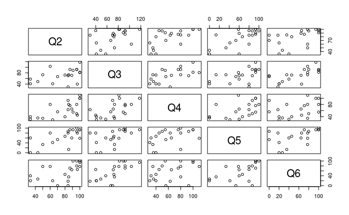

```r
plot(quiz)
```

## Part II: Every Quiz Is Exactly the Same?

### Problem 3

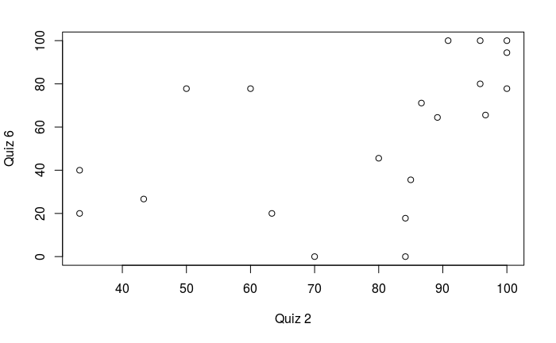

```r
plot(quiz$Q2,quiz$Q6,xlab= "Quiz 2", ylab= "Quiz 6")
```

### Problem 4

```r
cor(quiz$Q2,quiz$Q6)
```

```
[1] 0.4909938
```

Yes there is a positive association between the quiz percentages because the value is positive

### Problem 5

```r
bootstrap.cor <- function(x,y,B= 2000){
  data.x <- data.frame(x)
  data.y <- data.frame(y)
  boot.est <- vector(length= B)
  for(i in 1:B){
    boot.x <- data.x[sample(1:nrow(data.x),replace=TRUE),]
    boot.y <- data.y[sample(1:nrow(data.y),replace=TRUE),]
    boot.est[i] <- cor(boot.x,boot.y)
  }
  return(boot.est)
}
```

### Problem 6

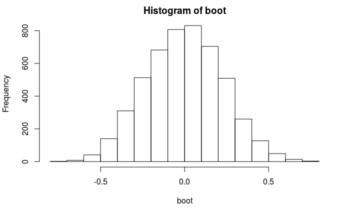

```r
boot <- bootstrap.cor(quiz$Q2,quiz$Q6,B= 5000)
hist(boot)
```

The bootstrap data from the correlation between quiz 2 and quiz 6 appear to be normally distributed around 0

### Problem 7

```r
quantile(boot,c(0.025,0.975))
```

```
      2.5%      97.5%
-0.4319947  0.4439362
```

```r
cor.test(quiz$Q2,quiz$Q6)$conf.int[1:2]
```

```
[1] 0.06192856 0.76688885
```

The bootstrap interval has a larger range of values than the normal interval. The lower bootstrap interval is also negative while the normal interal is positive. We can reject the null hypothesis and conclude that there is an association between the Quiz 2 and Quiz 6 scores. The significance level is 0.05.

## Part III: The “It” Factor

### Problem 8

```r
cov.mat <- cov(quiz)

cov(x = quiz$Q2, y = quiz$Q3)
```

```
[1] 230.7018
```

```r
cov.mat[1,2]
```

```
[1] 230.7018
```

These are the same.

### Problem 9

```r
eigen.vals <- eigen(cov.mat)$value
eigen.vals
```

```
[1] 2446.15631  611.37990  435.12267  221.17157   97.66563
```

It’s sorted greatest to least.

### Problem 10

```r
sum(eigen.vals)
```

```
[1] 3811.496
```

```r
sum(diag(cov.mat))
```

```
[1] 3811.496
```

These are the same.

### Problem 11

```r
eigen.vals[1]/sum(eigen.vals)
```

```
[1] 0.6417838
```

64.2% of the variance is captured by the first principal component analysis.

### Problem 12

```r
bootstrap.eigenratio <- function(mat, B = 2000){
?eigen
  cov.mat <- cov(mat)
  eigen.vals <- eigen(x=cov.mat)$value
  data.eigen <- data.frame(eigen.vals)
  eigen.ratio <- vector(length= B)
  for(i in 1:B){

    boot.est <- data.eigen[sample(1:nrow(data.eigen),replace=TRUE),]
    eigen.ratio[i] <- max(boot.est)/sum(boot.est)
  }

  return(eigen.ratio)
}
```

### Problem 13

```r
bootstrap.eigenratio.test <- bootstrap.eigenratio(mat = quiz, B = 5000)
bootstrap.eigenratio.test
```

[output not shown]

[output cut: 98 more lines]

```r
quantile(bootstrap.eigenratio.test, c(0.025, 0.975), na.rm = TRUE)
```

```
     2.5%     97.5%
0.2444739 0.7626753
```

We can confidently assign the proportions of the total variance in the scores between .24 and .76 to the largest principal component analysis.